# Generative Models: Gaussian, KDE, and GAN

Machine Learning for Finance

## Background

A risk analyst at a private wealth manager wants to compute the range of potential outcomes for a client’s retirement portfolio.

**CautionQuestion**

How might the analyst use Generative models like Gaussian parametric, nonparametric kernel density, and a GAN?

**NoteAnswer**

The analyst needs to forecast returns. Unlike point forecasts, we need a probabilistic range of forecasts. One approach is to use a Generative Model; i.e. a model that generates realistic simulations of the return process. By stringing together several days’ returns we can simulate how the initial client’s wealth could evolve through time. By repeating that process over many simulated paths, we create a range of outcomes that can be used to assess the risk embedded within the client’s portfolio.

Three Generative Models are i) parameteric density fitting, wherein we choose a distributional form (e.g. Gaussian) wherein we fit that form to the data, and then simulate from the estimated density, ii) Kernel Density estimation, which is a non parametric approach that uses the empirical distribution of the data to form a simulator, and iii) a Generative Adversarial Network (GAN), which trains a neural network generator to produce simulated returns that a second neural network (the discriminator) cannot distinguish from historical returns.

## Housekeeping

```r
cat("\014")  # clear console
```

```r
rm(list=ls())  # Clear the workspace

required_packages <- c("tidyverse", "scales", "knitr", "keras3")
missing_packages <- required_packages[!vapply(required_packages, requireNamespace,
                                               quietly = TRUE, FUN.VALUE = logical(1))]
if (length(missing_packages) > 0) {
  stop("Install these packages before rendering: ", paste(missing_packages, collapse = ", "))
}

library(tidyverse)
library(scales)
library(knitr)
library(here)

# Pin the Python virtualenv created by keras3::install_keras() explicitly.
# Without this, reticulate's automatic environment discovery can behave
# inconsistently depending on how R was launched (e.g. via Positron vs. a
# shell), and in some contexts attempts to provision an unrelated ephemeral
# environment instead of reusing the one already configured for keras3.
reticulate_venv <- file.path(Sys.getenv("USERPROFILE"), "Documents", ".virtualenvs", "r-keras")
if (dir.exists(reticulate_venv)) {
  reticulate::use_virtualenv(reticulate_venv, required = TRUE)
}
library(keras3)

source(here("Topics/Generative", "ReturnSimulation-Helpers.R"))

theme_set(
  theme_minimal(base_size = 12) +
    theme(
      legend.position = "bottom",
      panel.grid.minor = element_blank(),
      plot.title.position = "plot"
    )
)

set.seed(20260905)
keras3::set_random_seed(20260905)

# Simulation settings. These are fixed constants; the exercise is small enough
# that the full run completes quickly.
N_PATHS <- 1000L
SIMULATION_DAYS <- 252L
ONE_DAY_DRAWS <- 100000L
KDE_QUANTILE_DRAWS <- 20000L

# GAN settings. Kept small and trained for few epochs so that a GAN is fit
# separately for each of the four assets without materially slowing down
# rendering. See the "GAN model" section for what each setting controls.
GAN_Z_DIM <- 32L
GAN_HIDDEN_UNITS <- 64L
GAN_EPOCHS <- 50L
GAN_BATCH_SIZE <- 32L
GAN_LEARNING_RATE <- 2e-4

model_colors <- c(
  "Historical" = "grey35",
  "Gaussian" = "#0072B2",
  "KDE" = "#D55E00",
  "GAN" = "#009E73"
)

asset_levels <- c("Asset 1", "Asset 2", "Asset 3", "Asset 4")
```

`N_PATHS` is the number of simulated one-year paths per asset and model. `ONE_DAY_DRAWS` is the size of the large one-day sample used to compare fitted marginal distributions. `KDE_QUANTILE_DRAWS` controls the reference sample used for KDE interval and tail quantiles during validation.

## Data

**CautionTask**

Load the simulated returns. The returns were generated by `SimulatedData-ReturnDistributions.R` and stored in `data/KDE-returns.csv`.

```r
asset_returns <- read_csv(here("data", "KDE-returns.csv"),
                          show_col_types = FALSE) |>
  mutate(
    date = as.Date(date),
    asset_id = factor(asset_id, levels = asset_levels)
  )

sample_check <- asset_returns |>
  summarise(
    assets = n_distinct(asset_id),
    trading_days = n_distinct(date),
    observations = n(),
    first_date = min(date),
    last_date = max(date),
    missing_returns = sum(is.na(return)),
    minimum_observations_per_asset = min(table(asset_id)),
    maximum_observations_per_asset = max(table(asset_id))
  )
```

**NoteOutput**

Synthetic sample integrity checks

| assets | trading_days | observations | first_date | last_date | missing_returns | minimum_observations_per_asset | maximum_observations_per_asset |
| --- | --- | --- | --- | --- | --- | --- | --- |
| 4 | 1260 | 5040 | 2020-01-01 | 2024-10-29 | 0 | 1260 | 1260 |

The dates are synthetic weekday labels. Exchange holidays are intentionally outside the scope of the lesson.

### Calibration and validation samples

**CautionTask**

Use the first four years to fit the models and reserve the fifth year for validation.

```r
all_dates <- sort(unique(asset_returns$date))
calibration_dates <- all_dates[1:1008]
validation_dates <- all_dates[1009:1260]

calibration <- asset_returns |>
  filter(date %in% calibration_dates)

validation <- asset_returns |>
  filter(date %in% validation_dates)

split_check <- bind_rows(
  calibration |> summarise(sample = "Calibration", start = min(date), end = max(date),
                           days = n_distinct(date), observations = n()),
  validation |> summarise(sample = "Validation", start = min(date), end = max(date),
                          days = n_distinct(date), observations = n())
)
```

**NoteOutput**

Chronological calibration and validation samples

| sample | start | end | days | observations |
| --- | --- | --- | --- | --- |
| Calibration | 2020-01-01 | 2023-11-10 | 1008 | 4032 |
| Validation | 2023-11-13 | 2024-10-29 | 252 | 1008 |

**TipQuestion**

Why should we not evaluate the models only on the data used to fit them?

**NoteAnswer**

- A flexible model can look especially accurate in sample because it adapts closely to the calibration observations.
- Strong in-sample fit does not guarantee that the model will describe new returns well.
- A later validation period tests whether the fitted distribution generalizes.
- The validation observations must not influence parameter or bandwidth estimation.

## Exploratory data analysis

All distributional EDA and model estimation below use the calibration sample so that the validation year remains genuinely unseen.

```r
asset_summary <- calibration |>
  group_by(asset_id) |>
  summarise(distribution_summary(return), .groups = "drop")
```

**NoteOutput**

Calibration-period summaries for the four assets

| asset_id | mean | sd | skewness | excess_kurtosis | q01 | q05 | median | q95 | q99 |
| --- | --- | --- | --- | --- | --- | --- | --- | --- | --- |
| Asset 1 | 5e-04 | 0.0139 | -3.3503 | 13.3725 | -0.0664 | -0.0120 | 0.0027 | 0.0138 | 0.0173 |
| Asset 2 | 0e+00 | 0.0115 | -0.0867 | -0.2354 | -0.0285 | -0.0191 | 0.0001 | 0.0191 | 0.0245 |
| Asset 3 | -4e-04 | 0.0181 | -1.8305 | 8.9450 | -0.0693 | -0.0269 | 0.0011 | 0.0217 | 0.0341 |
| Asset 4 | -2e-04 | 0.0159 | -0.2676 | 3.3103 | -0.0475 | -0.0246 | 0.0002 | 0.0243 | 0.0384 |

**CautionTask**

Create time series plots of returns for each asset.

```r
calibration |>
  ggplot(aes(date, return)) +
  geom_line(linewidth = 0.3, color = "#3B6FB6") +
  facet_wrap(~ asset_id, ncol = 1, scales = "free_y") +
  scale_y_continuous(labels = percent) +
  labs(
    title = "Calibration-period daily returns",
    x = NULL,
    y = "Daily return"
  )
```

**NoteOutput**

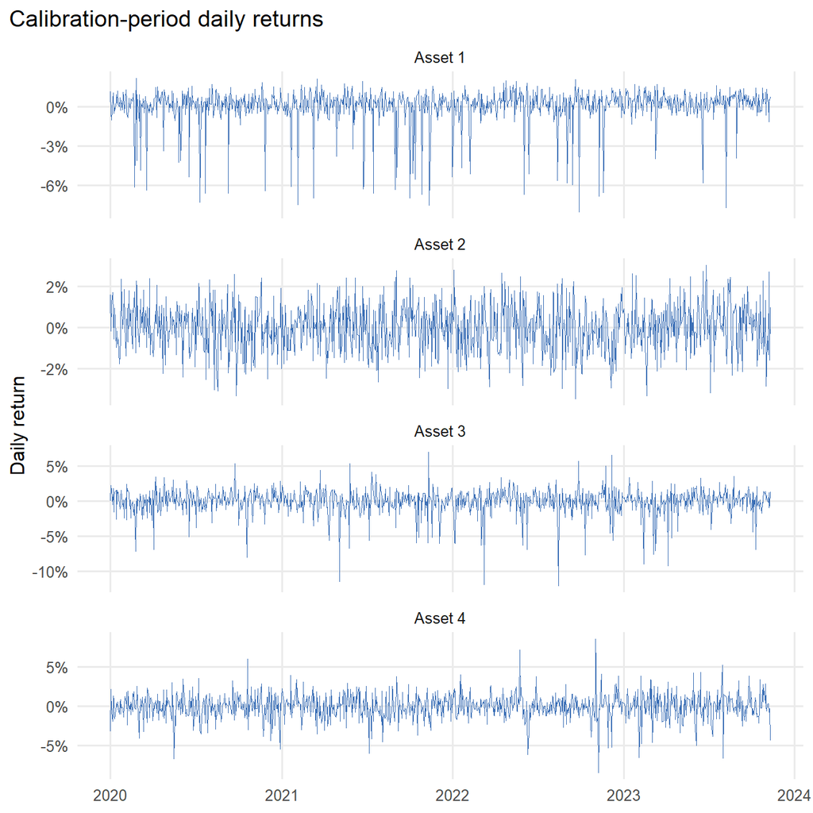

**CautionTask**

Create histograms of returns for each asset

```r
calibration |>
  ggplot(aes(return)) +
  geom_histogram(aes(y = after_stat(density)), bins = 45,
                 fill = "grey80", color = "white") +
  geom_density(color = "grey25", linewidth = 0.8) +
  facet_wrap(~ asset_id, scales = "free", ncol = 2) +
  scale_x_continuous(labels = percent) +
  labs(
    title = "Return distributions for the four assets",
    x = "Daily return",
    y = "Density"
  )
```

**NoteOutput**

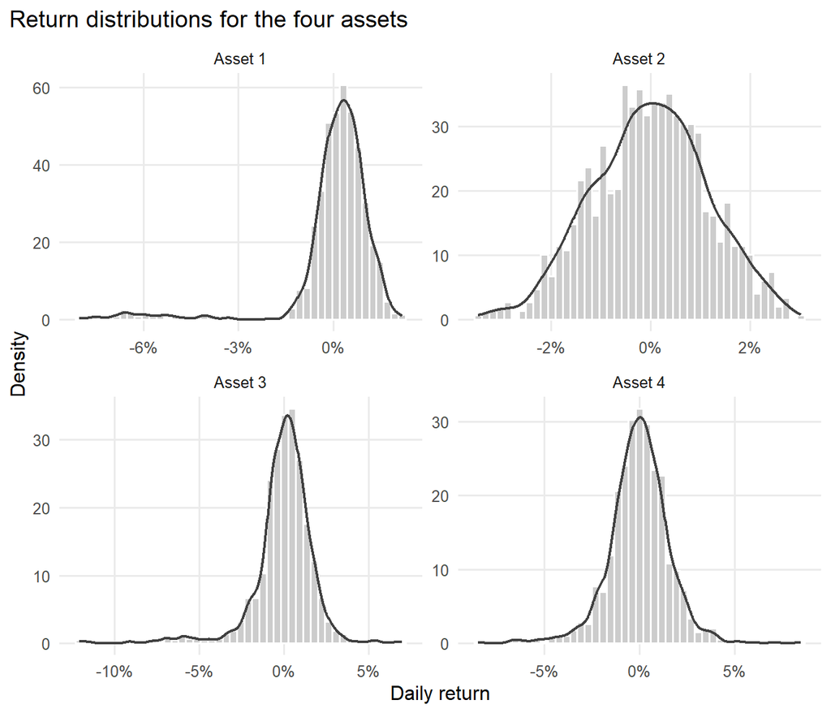

**CautionTask**

Create QQ plots of the 4 assets

```r
calibration |>
  ggplot(aes(sample = return)) +
  stat_qq(alpha = 0.45, size = 0.8) +
  stat_qq_line(color = "#D55E00", linewidth = 0.8) +
  facet_wrap(~ asset_id, scales = "free", ncol = 2) +
  labs(
    title = "Gaussian Q–Q plots",
    x = "Theoretical Gaussian quantile",
    y = "Observed return quantile"
  )
```

**NoteOutput**

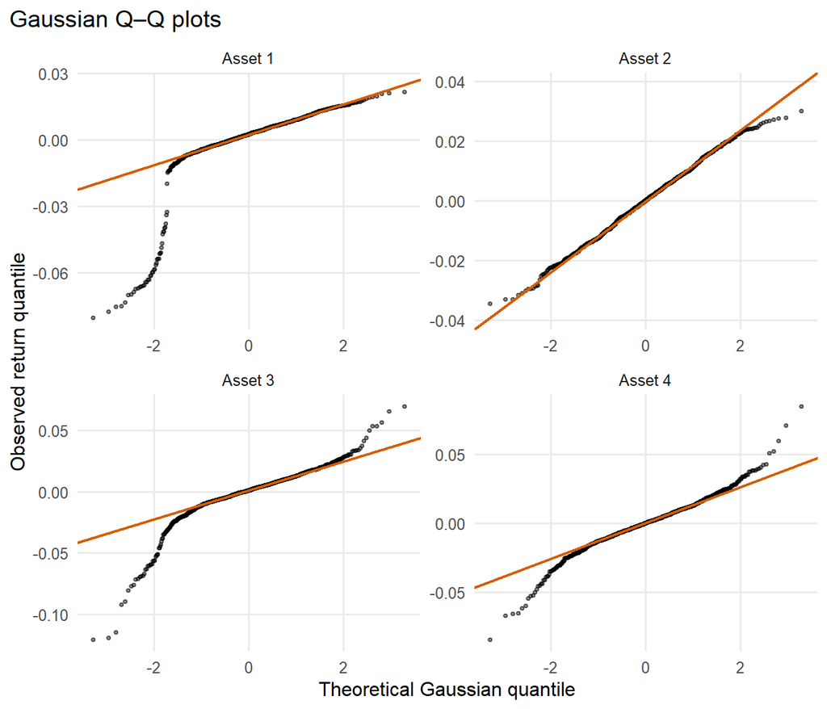

**TipQuestion**

Which features would make a Gaussian model potentially inadequate?

**NoteAnswer**

- substantial skewness;
- tails heavier than those of a Gaussian distribution;
- systematic tail deviations from the reference line in a Gaussian Q–Q plot;
- multiple modes or mixture-like features; and
- extreme losses that occur more frequently than a fitted Gaussian predicts.

**CautionTask**

For each asset, recommend the Gaussian model, KDE, or a GAN. Justify the recommendation using the histogram, Q–Q plot, skewness, kurtosis, and tail quantiles.

## Gaussian parametric model

### Estimation

For asset $i$, estimate the calibration-period mean and standard deviation:

$$\widehat{\mu}_i=\frac{1}{T}\sum_{t=1}^{T}r_{it},
\qquad
\widehat{\sigma}_i=
\sqrt{\frac{1}{T-1}\sum_{t=1}^{T}(r_{it}-\widehat{\mu}_i)^2}.$$

The fitted model assumes:

$$r_{i,t}^{\mathrm{sim}}\sim N\left(\widehat{\mu}_i,\widehat{\sigma}_i^2\right).$$

**CautionTask**

Summarize returns from the calibration set.

```r
gaussian_estimates <- calibration |>
  group_by(asset_id) |>
  summarise(
    mu = mean(return),
    sigma = sd(return),
    .groups = "drop"
  )
```

**NoteOutput**

Gaussian parameter estimates

| asset_id | mu | sigma |
| --- | --- | --- |
| Asset 1 | 0.00053 | 0.01394 |
| Asset 2 | -0.00004 | 0.01151 |
| Asset 3 | -0.00045 | 0.01809 |
| Asset 4 | -0.00016 | 0.01593 |

**TipQuestion**

If the Gaussian simulation matches an asset’s mean and standard deviation, does it reproduce the entire distribution?

**NoteAnswer**

- No. Matching the first two moments does not ensure that the model matches skewness, kurtosis, tail quantiles, or multiple modes.
- The Gaussian assumption imposes symmetry, zero excess kurtosis, and a particular relationship among all quantiles.
- The estimates also contain sampling error, even when the Gaussian assumption is correct.

### Simulation

**TipQuestion**

How can we use a Gaussian parametric simulation to achieve the risk manager’s goal?

**NoteAnswer**

- Use each asset’s calibration-period returns to estimate its mean and standard deviation.
- Assume future daily returns follow a Gaussian distribution with those estimated parameters.
- Draw many sequences of daily returns from the fitted distribution.
- Compound each sequence into a possible one-year wealth path.
- Summarize the paths using quantiles, loss probabilities, Value at Risk, and Expected Shortfall.
- The method is parametric because a small number of estimated parameters, together with the Gaussian assumption, determine the entire distribution.

A single Gaussian draw for asset $i$ is simply $r^{\mathrm{sim}}=\widehat{\mu}_i +\widehat{\sigma}_i\,z$ with $z\sim N(0,1)$. The helper `draw_gaussian()` returns a vector of such draws.

**CautionTask**

Create a temporary subset to focus on Asset 2

```r
set.seed(4127)

gaussian_example <- gaussian_estimates |>
  filter(asset_id == "Asset 2")
tibble(simulated_return = draw_gaussian(10, gaussian_example$mu,
                                        gaussian_example$sigma)) |>
  mutate(simulated_return = percent(simulated_return, accuracy = 0.01)) |>
  kable(caption = "Ten illustrative Gaussian draws for Asset 2")
```

**NoteOutput**

Ten illustrative Gaussian draws for Asset 2

| simulated_return |
| --- |
| 0.63% |
| -2.43% |
| -0.82% |
| 0.01% |
| -0.85% |
| -0.12% |
| 0.25% |
| -1.57% |
| -0.06% |
| 0.27% |

## KDE model

### KDE Intuition

**TipQuestion**

Can you describe the purpose and mechanics of KDE?

**NoteAnswer**

KDE is a nonparametric approach to simulation

- Parametric simulation: assume a specific distribution (e.g., Gaussian), estimate a few parameters, and simulate from that assumed shape.
- KDE simulation: make no global distributional assumption; instead, approximate the density as a sum of small local densities centered at the observed data, then simulate from that empirical shape.
- The Kernel density function is $\frac{1}{Th}\sum_{i=1}^{T}K(\frac{x-x_{i}}{h})$, where $N$ is the number of observations, $h>0$ is the smoothing parameter (aka bandwidth), and $K(.)$ is the kernel function, which integrates to 1.
- Many Kernels are possible, such as Gaussian, Uniform, Triangular, etc…

How KDE builds a smooth analogue of a histogram

1. Form empirical distribution

If we treat the raw data as a density:
$$\hat f_{\text{emp}}(x) = \frac{1}{T}\sum_{i=1}^T \delta(x - x_i).$$

- Each observation is a point mass aka ``spike”
- Graphically: vertical spikes at the observed values
- This is the raw input into KDE
2. KDE: replace spikes with kernels

Recall that a histogram would smooth the spikes into bins. Instead of bins, the KDE:

- Replaces each spike $\delta(x - x_i)$ with a small smooth bump
- The bump is the kernel, centered at $x_i$

$$\delta(x - x_i)
\;\longrightarrow\;
\frac{1}{h}K\!\left(\frac{x - x_i}{h}\right)$$

- Each observation contributes a local density ``hill’’
- Shape determined by the kernel $K$
- Width controlled by the bandwidth $h$
3. Build the density curve by stacking bumps

The KDE density curve is simply:
$$\hat f(x) = \frac{1}{T}\sum_{i=1}^T
\text{(kernel bump centered at } x_i\text{)}.$$

Graphically:

- Place one kernel at each data point
- Scale each kernel so its total area equals $1/T$
- Add all kernels together

The resulting density curve is:

- Smooth (if the kernel is smooth)
- Continuous (no bins)
- Higher in regions where many kernel bumps overlap

**TipQuestion**

How simulate from the KDE?

**NoteAnswer**

- Randomly select an observed data point $x_i$ (each with probability $1/T$)
- Draw noise $\varepsilon$ from the kernel, scaled by the bandwidth
  - Kernel controls the shape, while Bandwidth controls the scale
  - A wider bandwidth stretches the kernel so that noise draws are larger
  - For consistency we usually use the same bandwidth for simulation as we used for estimation
- Form a simulated draw:
  $$\tilde{x} = x_i + \varepsilon$$

### Estimation

For asset $i$, the KDE is:

$$\widehat f_i(r)=\frac{1}{T h_i}\sum_{t=1}^{T}
K\left(\frac{r-r_{it}}{h_i}\right),$$

where $K$ is the kernel and $h_i$ is the bandwidth. We use a Gaussian kernel and the normal-reference bandwidth (`bw.nrd0`) for the main comparison.

**CautionTask**

Estimate the bandwidth for each asset within the calibration sample.

```r
kde_estimates <- calibration |>
  group_by(asset_id) |>
  summarise(
    bw_nrd0 = bw.nrd0(return),
    .groups = "drop"
  )
```

**NoteOutput**

KDE bandwidth estimates

| asset_id | bw_nrd0 |
| --- | --- |
| Asset 1 | 0.00156 |
| Asset 2 | 0.00260 |
| Asset 3 | 0.00267 |
| Asset 4 | 0.00294 |

### Simulation

**TipQuestion**

How can we use KDE-based simulation to achieve the risk manager’s goal?

**NoteAnswer**

- Estimate each asset’s return density without assuming that it is Gaussian.
- Construct the density by placing a kernel around every calibration return.
- Draw daily returns from the fitted KDE and compound those draws into one-year wealth paths.
- Summarize the paths with the same risk measures used for the Gaussian model.
- KDE can reproduce skewness, heavy tails, and mixtures, although the result depends importantly on the bandwidth.

With a Gaussian kernel, an exact KDE draw has a transparent smoothed-bootstrap interpretation:

1. Select a calibration return $r_j$ at random.
2. Draw $\varepsilon\sim N(0,h^2)$.
3. Set $r^{\mathrm{sim}}=r_j+\varepsilon$.

**CautionTask**

Focus on Asset 3. Draw 10 samples via draw_kde using this asset’s estimated bandwidth.

```r
example_id <- "Asset 3"
example_returns <- calibration |>
  filter(asset_id == example_id) |>
  pull(return)
example_bandwidth <- bw.nrd0(example_returns)

set.seed(6503)
example_kde_draws <- draw_kde(
  n = 10,
  x = example_returns,
  bandwidth = example_bandwidth
)
```

**NoteOutput**

Ten illustrative KDE draws for Asset 3

| simulated_return |
| --- |
| 0.54% |
| 0.75% |
| 5.01% |
| -4.37% |
| -1.06% |
| 1.30% |
| 0.15% |
| 1.98% |
| -0.30% |
| 1.35% |

**TipQuestion**

How does KDE simulation differ from simply resampling historical returns?

**NoteAnswer**

- Ordinary resampling can reproduce only values observed in the calibration sample.
- Gaussian-kernel KDE first selects an observation and then adds continuous noise controlled by the bandwidth.
- It can therefore generate returns that were not observed exactly, including values slightly beyond the historical range.
- KDE remains a model: its kernel, bandwidth, sample, and stationarity assumptions all affect its output.
- Because arithmetic returns cannot fall below $-100\%$, the helper function resamples any such draw. Under the calibrated daily distributions, this event should be exceptionally rare. The rule is explicit rather than silently clipping a draw to an arbitrary boundary.

### Bandwidth and the bias–variance tradeoff

**CautionTask**

Focus on Asset 3. Construct a plot of the empirical density with bandwidth 0.5. Repeat for 1 and 2.

```r
adjust_values <- c(0.5, 1, 2)

bandwidth_curves <- map_dfr(adjust_values, function(adjust_value) {
  estimate <- density(example_returns, bw = "nrd0", adjust = adjust_value,
                      n = 1024)
  tibble(
    return = estimate$x,
    density = estimate$y,
    bandwidth = paste0("adjust = ", adjust_value)
  )
})


ggplot() +
  geom_histogram(
    data = tibble(return = example_returns),
    aes(return, y = after_stat(density)),
    bins = 45, fill = "grey85", color = "white"
  ) +
  geom_line(
    data = bandwidth_curves,
    aes(return, density, color = bandwidth),
    linewidth = 0.9
  ) +
  scale_x_continuous(labels = percent) +
  labs(
    title = "The KDE changes substantially with bandwidth",
    subtitle = paste("Illustration using", example_id),
    x = "Daily return",
    y = "Density",
    color = NULL
  )
```

**NoteOutput**

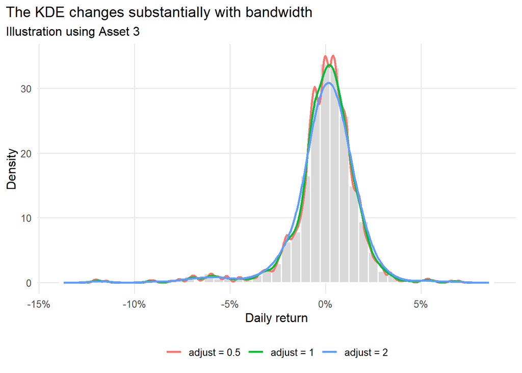

**TipQuestion**

What happens when we decrease or increase the KDE bandwidth?

**NoteAnswer**

- A smaller bandwidth produces a more irregular density that follows local sample features closely. It can reveal structure, but it can also fit noise.
- A larger bandwidth produces a smoother, lower-variance estimate.
- Excessive smoothing can conceal skewness, tail structure, or mixtures.
- Bandwidth selection therefore illustrates the bias–variance tradeoff.

## GAN model

### GAN Intuition

**TipQuestion**

Can you describe the purpose and mechanics of a GAN?

**NoteAnswer**

A GAN is a different kind of nonparametric simulator than KDE. Rather than building a density explicitly from the data, it trains two competing neural networks:

- The **generator** maps a draw of low-dimensional random noise $z\sim N(0,I)$ to a simulated return $r^{\mathrm{sim}}=G(z)$.
- The **discriminator** $D(\cdot)$ is trained to output the probability that a return it is shown came from the historical sample rather than from the generator.
- The generator is trained to fool the discriminator: it is updated to increase $D(G(z))$, i.e. to produce returns the discriminator mistakes for real ones.
- Training alternates between improving the discriminator at distinguishing real from fake, and improving the generator at deceiving the current discriminator.
- At convergence (in principle) the generator’s output distribution matches the historical return distribution closely enough that the discriminator cannot do better than guessing.

Unlike KDE, the GAN does not place an explicit kernel around each observation, and unlike the Gaussian model, it does not assume a parametric family. However, because training solves a difficult adversarial optimization problem, a GAN’s fit can depend heavily on network size, training length, and even the random seed used to initialize it.

### Estimation

For each asset we estimate the calibration-period mean $\widehat\mu_i$ and standard deviation $\widehat\sigma_i$, exactly as in the Gaussian model, and use them only to standardize returns before training:

$$\tilde r_{it} = \frac{r_{it}-\widehat\mu_i}{\widehat\sigma_i}.$$

The generator and discriminator are trained on the standardized returns $\tilde r_{it}$, and the generator’s output is rescaled back to the original units when simulating.

Both networks are small feedforward networks: the generator takes a `GAN_Z_DIM`-dimensional noise vector, passes it through two hidden layers with leaky-ReLU activations, and outputs a single simulated (standardized) return. The discriminator takes a single return and passes it through hidden layers of the same sizes before a sigmoid output representing the estimated probability that the return was historical rather than simulated.

**TipQuestion**

What is the role of the number of training epochs?

**NoteAnswer**

- One epoch corresponds to one full pass of alternating generator/discriminator minibatch updates.
- More epochs give the generator more opportunity to learn finer features of the historical return distribution, including higher-order moments such as skewness and kurtosis.
- Training a GAN is an adversarial optimization problem, not a convex one: more epochs do not guarantee monotonic improvement. Training can also become unstable, oscillate, or collapse onto too narrow a range of outputs (“mode collapse”).
- We use a small network and few training epochs per asset so that this document renders quickly. A production use of this method would typically require more careful tuning, a larger network, and many more epochs, at the cost of a materially longer training time.

**CautionTask**

Train a GAN on the calibration-period returns for each asset.

```r
gan_fits <- setNames(vector("list", length(asset_levels)), asset_levels)

for (i in seq_along(asset_levels)) {
  id <- asset_levels[i]
  keras3::set_random_seed(300000 + i)

  gan_fits[[id]] <- train_gan(
    calibration |> filter(asset_id == id) |> pull(return),
    z_dim = GAN_Z_DIM,
    hidden_units = GAN_HIDDEN_UNITS,
    epochs = GAN_EPOCHS,
    batch_size = GAN_BATCH_SIZE,
    learning_rate = GAN_LEARNING_RATE,
    asset_name = id
  )
}

gan_scaling <- tibble(
  asset_id = asset_levels,
  mu = map_dbl(gan_fits, "mu"),
  sd = map_dbl(gan_fits, "sd")
)
```

**NoteOutput**

Scaling parameters used to standardize returns before GAN training

| asset_id | mu | sd |
| --- | --- | --- |
| Asset 1 | 0.00053 | 0.01394 |
| Asset 2 | -0.00004 | 0.01151 |
| Asset 3 | -0.00045 | 0.01809 |
| Asset 4 | -0.00016 | 0.01593 |

**TipQuestion**

If the GAN’s scaling step matches an asset’s mean and standard deviation, does the GAN reproduce the entire distribution?

**NoteAnswer**

- No, and for a different reason than with the Gaussian model. The scaling step only fixes the location and scale used as inputs to training; it does not constrain what the generator actually learns to output.
- The generator can learn a standardized output distribution whose own mean or standard deviation differs from the training data, particularly if training has not converged well.
- Any resemblance to the historical skewness, kurtosis, or tail behavior is entirely a byproduct of adversarial training, with no explicit mechanism enforcing it, unlike KDE’s bandwidth-controlled smoothing of observed returns.

### Simulation

**TipQuestion**

How can we use GAN-based simulation to achieve the risk manager’s goal?

**NoteAnswer**

- Train a generator network on each asset’s calibration-period returns, standardized to have zero mean and unit variance.
- Draw many low-dimensional noise vectors, pass them through the trained generator, and rescale the output back to the original return units.
- Compound simulated daily returns into one-year wealth paths exactly as with the Gaussian and KDE models.
- Summarize the simulated paths using the same quantiles, loss probabilities, Value at Risk, and Expected Shortfall measures.
- The GAN is nonparametric in the same broad sense as KDE: no distributional family is imposed. It differs from KDE in how it builds the simulator – through adversarial training of a neural network rather than through explicit kernel smoothing of the data.

**CautionTask**

Using the same Asset 3 example as for KDE, draw 10 samples from the fitted GAN.

```r
set.seed(7604)
example_gan_draws <- draw_gan(10, gan_fits[[example_id]])
```

**NoteOutput**

Ten illustrative GAN draws for Asset 3

| simulated_return |
| --- |
| 0.31% |
| 0.87% |
| 0.89% |
| -0.69% |
| 0.47% |
| 2.48% |
| -1.21% |
| 2.00% |
| -0.20% |
| 2.13% |

### GAN training stability and fit diagnostics

Unlike the Gaussian model (a closed-form fit) or KDE (a deterministic function of the data and bandwidth), a GAN’s fit depends on its random weight initialization and on the path taken by adversarial training. The same architecture and number of epochs, applied to the same data, can produce generators of noticeably different quality depending on the random seed.

**CautionTask**

For the Asset 3 GAN, simulate 200 replicate return paths of the same length as the calibration sample. For each path compute the mean, standard deviation, skewness, and excess kurtosis, and compare the distribution of each statistic (across paths) to the single historical calibration value.

```r
GAN_DIAGNOSTIC_PATHS <- 200L
gan_path_length <- length(example_returns)

set.seed(260000)
gan_path_matrix <- matrix(
  draw_gan(GAN_DIAGNOSTIC_PATHS * gan_path_length, gan_fits[[example_id]]),
  nrow = GAN_DIAGNOSTIC_PATHS, ncol = gan_path_length
)

gan_path_stats <- tibble(
  path_id = seq_len(GAN_DIAGNOSTIC_PATHS),
  mean = apply(gan_path_matrix, 1, mean),
  sd = apply(gan_path_matrix, 1, sd),
  skewness = apply(gan_path_matrix, 1, sample_skewness),
  excess_kurtosis = apply(gan_path_matrix, 1, sample_excess_kurtosis)
)

gan_historical_stats <- distribution_summary(example_returns) |>
  select(mean, sd, skewness, excess_kurtosis)

gan_path_diff_long <- gan_path_stats |>
  mutate(
    mean = mean - gan_historical_stats$mean,
    sd = sd - gan_historical_stats$sd,
    skewness = skewness - gan_historical_stats$skewness,
    excess_kurtosis = excess_kurtosis - gan_historical_stats$excess_kurtosis
  ) |>
  pivot_longer(-path_id, names_to = "statistic", values_to = "value")

ggplot(gan_path_diff_long, aes(statistic, value)) +
  geom_hline(yintercept = 0, linetype = "dashed", color = "gray40") +
  geom_violin(alpha = 0.5, trim = TRUE, fill = model_colors[["GAN"]]) +
  geom_jitter(width = 0.08, height = 0, alpha = 0.15, size = 0.8) +
  stat_summary(fun = mean, geom = "point", shape = 21, size = 3, fill = "white") +
  labs(
    title = paste("GAN simulated path minus historical statistic,", example_id),
    subtitle = "Each point is one simulated path; width shows the spread across 200 paths",
    y = "Simulated \u2212 historical",
    x = NULL
  )
```

**NoteOutput**

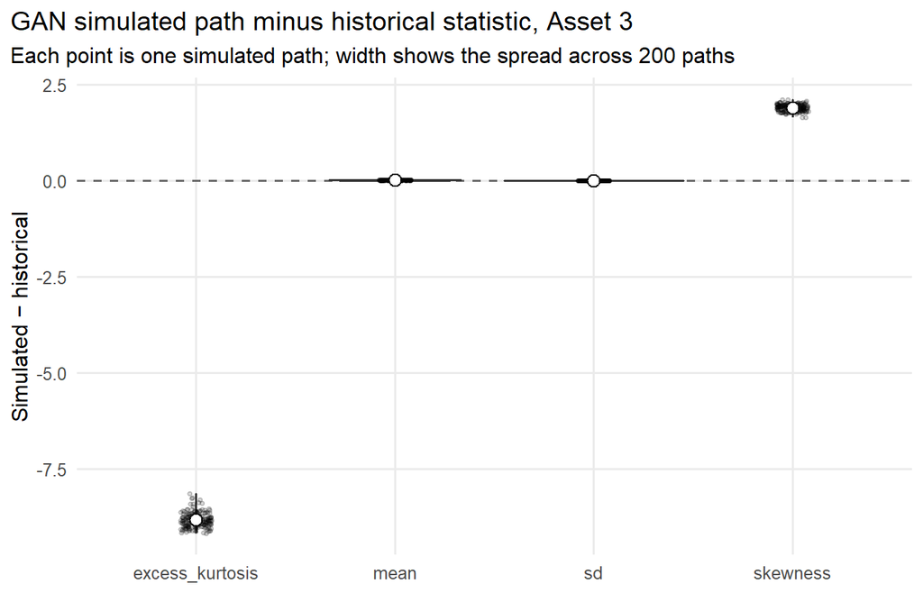

**TipQuestion**

Does the GAN do a good job at mimicking Asset 3 returns?

**NoteAnswer**

Not at this training budget. Asset 3’s calibration returns have mean $\approx-0.04\%$, standard deviation $\approx1.81\%$, skewness $\approx-1.83$, and excess kurtosis $\approx8.9$ – a pronounced left skew and heavy tails. Averaged across the 200 simulated replicate paths, the fitted generator instead produces a mean of roughly $+0.8\%$ per day, a standard deviation of roughly $1.4\%$ (about 22% below historical), a skewness near $0$, and an excess kurtosis near $0$.

- The GAN gets the order of magnitude of daily volatility roughly right, but understates it, and it gets the sign and magnitude of the mean wrong by an amount that is large relative to how close to zero the true daily mean is.
- More importantly, it misses the defining shape features of this asset: the strong negative skew and heavy left tail are almost entirely absent from the simulated paths, which look close to symmetric and only mildly non-Gaussian.
- These are exactly the features that let KDE outperform the Gaussian model for Asset 3 earlier in this document. KDE reproduces them because every draw is tied to an actual historical observation; the GAN has no such structural guarantee, and with a small network and few epochs it has not learned them.

## In-sample fit

### In-sample fitted densities

**CautionTask**

For each asset, identify the features that the Gaussian model misses and assess whether the KDE and GAN appear to capture genuine structure or local sampling noise.

A GAN has no closed-form density, so as an approximate density curve for plotting we draw a large sample from each asset’s trained generator and smooth it with a KDE – the same plug-in approach used later for the GAN’s validation log score.

```r
set.seed(240000)

density_comparison <- calibration |>
  group_by(asset_id) |>
  group_modify(~ {
    x <- .x$return
    grid <- seq(min(x) - 0.15 * diff(range(x)),
                max(x) + 0.15 * diff(range(x)), length.out = 800)
    kde_fit <- density(x, bw = "nrd0", from = min(grid), to = max(grid), n = 800)
    gan_sample <- draw_gan(KDE_QUANTILE_DRAWS, gan_fits[[as.character(.y$asset_id)]])
    gan_density <- kde_density_at(grid, gan_sample, bw.nrd0(gan_sample))
    bind_rows(
      tibble(return = grid, density = dnorm(grid, mean(x), sd(x)), model = "Gaussian"),
      tibble(return = kde_fit$x, density = kde_fit$y, model = "KDE"),
      tibble(return = grid, density = gan_density, model = "GAN")
    )
  }) |>
  ungroup()


ggplot() +
  geom_histogram(
    data = calibration,
    aes(return, y = after_stat(density)),
    bins = 45, fill = "grey85", color = "white"
  ) +
  geom_line(
    data = density_comparison,
    aes(return, density, color = model),
    linewidth = 0.9
  ) +
  facet_wrap(~ asset_id, scales = "free", ncol = 2) +
  scale_color_manual(values = model_colors[c("Gaussian", "KDE", "GAN")]) +
  scale_x_continuous(labels = percent) +
  labs(
    title = "Gaussian, KDE, and GAN fits to calibration returns",
    x = "Daily return",
    y = "Density",
    color = NULL
  )
```

**NoteOutput**

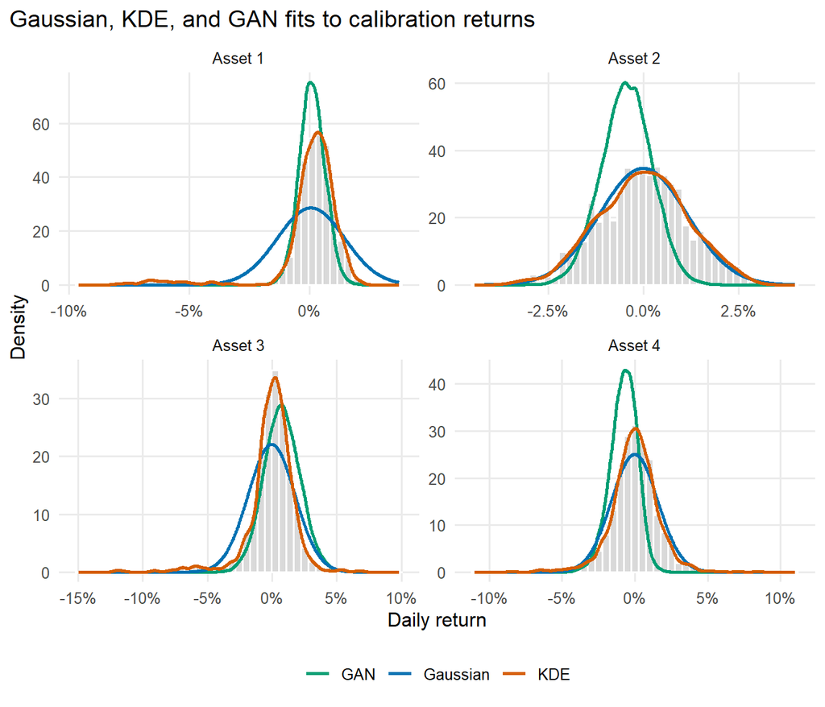

**TipQuestion**

Does the closer-looking KDE fit establish that KDE is the better model?

**NoteAnswer**

- No. KDE usually fits the calibration sample more closely because it is more flexible.
- Some fitted features may be sample-specific and may not recur.
- The validation year provides a better test of whether the additional flexibility generalizes.
- The GAN’s in-sample fit depends on how well adversarial training converged, which is not guaranteed even by construction. A visibly worse in-sample fit for the GAN does not necessarily mean it is the worse model out of sample – but, unlike KDE, it also is not evidence of superior flexibility; it may simply reflect incomplete training.

### Compare simulated one-day returns

**CautionTask**

For each asset, draw a large one-day simulation sample from each fitted model and compare its distribution with the calibration returns.

```r
set.seed(1401)

one_day_comparison <- map_dfr(asset_levels, function(id) {
  historical <- calibration |> filter(asset_id == id) |> pull(return)
  fitted <- fit_marginal_models(historical)

  bind_rows(
    distribution_summary(historical) |> mutate(model = "Historical"),
    distribution_summary(draw_gaussian(ONE_DAY_DRAWS, fitted$mu, fitted$sigma)) |>
      mutate(model = "Gaussian"),
    distribution_summary(draw_kde(ONE_DAY_DRAWS, historical, fitted$bw_nrd0)) |>
      mutate(model = "KDE"),
    distribution_summary(draw_gan(ONE_DAY_DRAWS, gan_fits[[id]])) |>
      mutate(model = "GAN")
  ) |>
    mutate(asset_id = id, .before = 1)
})
```

**NoteOutput**

Historical and simulated one-day return distributions

| asset_id | mean | sd | skewness | excess_kurtosis | q01 | q05 | median | q95 | q99 | model |
| --- | --- | --- | --- | --- | --- | --- | --- | --- | --- | --- |
| Asset 1 | 0.00053 | 0.01394 | -3.35025 | 13.37252 | -0.06638 | -0.01201 | 0.00271 | 0.01383 | 0.01730 | Historical |
| Asset 1 | 0.00058 | 0.01396 | 0.00618 | -0.00030 | -0.03181 | -0.02234 | 0.00059 | 0.02352 | 0.03315 | Gaussian |
| Asset 1 | 0.00054 | 0.01405 | -3.27566 | 12.90782 | -0.06687 | -0.01286 | 0.00272 | 0.01413 | 0.01822 | KDE |
| Asset 1 | 0.00105 | 0.00538 | 0.06802 | 0.15400 | -0.01143 | -0.00763 | 0.00100 | 0.01001 | 0.01402 | GAN |
| Asset 2 | -0.00004 | 0.01151 | -0.08670 | -0.23544 | -0.02852 | -0.01905 | 0.00013 | 0.01911 | 0.02449 | Historical |
| Asset 2 | -0.00006 | 0.01153 | 0.00163 | -0.01268 | -0.02679 | -0.01902 | -0.00009 | 0.01891 | 0.02667 | Gaussian |
| Asset 2 | -0.00012 | 0.01183 | -0.08318 | -0.22612 | -0.02821 | -0.01964 | 0.00012 | 0.01947 | 0.02570 | KDE |
| Asset 2 | -0.00435 | 0.00664 | -0.12107 | 0.12598 | -0.02056 | -0.01549 | -0.00421 | 0.00629 | 0.01075 | GAN |
| Asset 3 | -0.00045 | 0.01809 | -1.83050 | 8.94497 | -0.06927 | -0.02688 | 0.00112 | 0.02173 | 0.03411 | Historical |
| Asset 3 | -0.00044 | 0.01808 | 0.00875 | -0.01231 | -0.04230 | -0.03021 | -0.00045 | 0.02934 | 0.04168 | Gaussian |
| Asset 3 | -0.00038 | 0.01827 | -1.76793 | 8.56809 | -0.07065 | -0.02736 | 0.00129 | 0.02226 | 0.03635 | KDE |
| Asset 3 | 0.00764 | 0.01403 | 0.06122 | 0.10917 | -0.02457 | -0.01518 | 0.00748 | 0.03096 | 0.04131 | GAN |
| Asset 4 | -0.00016 | 0.01593 | -0.26758 | 3.31031 | -0.04753 | -0.02458 | 0.00023 | 0.02432 | 0.03840 | Historical |
| Asset 4 | -0.00019 | 0.01598 | 0.00802 | -0.01102 | -0.03721 | -0.02643 | -0.00018 | 0.02621 | 0.03688 | Gaussian |
| Asset 4 | -0.00023 | 0.01623 | -0.23782 | 3.07507 | -0.04913 | -0.02567 | 0.00004 | 0.02444 | 0.03951 | KDE |
| Asset 4 | -0.00768 | 0.00931 | -0.35279 | 0.26694 | -0.03201 | -0.02403 | -0.00709 | 0.00649 | 0.01188 | GAN |

**TipQuestion**

Why can KDE-simulated volatility be slightly higher than historical volatility?

**NoteAnswer**

- A Gaussian-kernel KDE draw equals a sampled historical return plus independent Gaussian noise.
- The added noise has variance $h^2$, so the fitted KDE variance is approximately the empirical variance plus $h^2$.
- A larger bandwidth therefore smooths the density and increases the variance of simulated draws.
- Variance-corrected smoothed bootstraps exist, but we retain the ordinary KDE here so that the simulation corresponds directly to the density we fitted.

**TipQuestion**

Why can the Gaussian model match mean and volatility while producing different tail-risk estimates?

**NoteAnswer**

- Mean and standard deviation describe only two aspects of a distribution.
- Tail quantiles also depend on skewness, kurtosis, and other features of the distributional shape.
- A Gaussian model imposes its tail shape; KDE estimates a more flexible shape from the calibration observations.

**TipQuestion**

Should we expect the GAN’s one-day moments to match the Gaussian model’s by construction, the way KDE’s roughly do?

**NoteAnswer**

- No. KDE’s one-day mean and variance are tied closely to the empirical mean and variance by construction (plus a small bandwidth-driven variance inflation), because every draw is a historical observation plus kernel noise.
- The GAN has no such built-in link. Its one-day mean, standard deviation, skewness, and kurtosis are whatever the trained generator happens to produce, so they can deviate further from the historical values – more so than KDE, and in either direction – particularly for a small network trained for relatively few epochs.
- This is the practical cost of the GAN’s added flexibility: it has no guardrail analogous to a bandwidth that keeps simulated draws anchored near the data.

## Out-of-sample

### Simulate one-year paths

Each path contains 252 simulated daily arithmetic returns. Starting with wealth of 1, path $p$ for asset $i$ evolves as:

$$W_{i,p,\tau}=\prod_{s=1}^{\tau}(1+r_{i,p,s}^{\mathrm{sim}}).$$

**TipQuestion**

What does one simulated path represent?

**NoteAnswer**

- One path is one model-generated version of the asset’s next 252 trading days.
- The paths are alternative future years, not additional assets.
- More paths reduce Monte Carlo noise, but they do not provide more historical information or remove model risk.

**CautionTask**

Use the custom “simulate_paths” function across our assets for the pre-defined number of paths and simulations.

```r
path_summaries <- list()
path_results <- list()

for (i in seq_along(asset_levels)) {
  id <- asset_levels[i]
  x <- calibration |> filter(asset_id == id) |> pull(return)
  bandwidth <- bw.nrd0(x)

  for (model_name in c("Gaussian", "KDE", "GAN")) {
    set.seed(500000 + i * 10 + match(model_name, c("Gaussian", "KDE", "GAN")))

    result <- simulate_paths(
      x = x,
      model = model_name,
      n_paths = N_PATHS,
      horizon = SIMULATION_DAYS,
      bandwidth = bandwidth,
      gan_fit = gan_fits[[id]],
      keep_paths = TRUE
    )

    path_summaries[[paste(id, model_name, sep = "__")]] <-
      result$summary |> mutate(asset_id = id, .before = 1)
    path_results[[paste(id, model_name, sep = "__")]] <- result
  }
}

path_summary <- bind_rows(path_summaries) |>
  mutate(asset_id = factor(asset_id, levels = asset_levels))
```

**NoteOutput**

One-year simulation summaries by asset and model

| asset_id | model | median_terminal_wealth | terminal_wealth_q05 | terminal_wealth_q95 | probability_below_one | return_q05 | loss_var_95 | loss_es_95 | median_max_drawdown | max_drawdown_q95 |
| --- | --- | --- | --- | --- | --- | --- | --- | --- | --- | --- |
| Asset 1 | Gaussian | 1.1205 | 0.7841 | 1.5846 | 0.289 | -0.2159 | 0.2159 | 0.2945 | 0.1783 | 0.3236 |
| Asset 1 | KDE | 1.1238 | 0.7569 | 1.6049 | 0.300 | -0.2431 | 0.2431 | 0.3156 | 0.1862 | 0.3687 |
| Asset 1 | GAN | 1.2958 | 1.1185 | 1.4939 | 0.001 | 0.1185 | -0.1185 | -0.0842 | 0.0405 | 0.0723 |
| Asset 2 | Gaussian | 0.9651 | 0.7220 | 1.3425 | 0.562 | -0.2780 | 0.2780 | 0.3221 | 0.1921 | 0.3380 |
| Asset 2 | KDE | 0.9598 | 0.7198 | 1.3268 | 0.579 | -0.2802 | 0.2802 | 0.3263 | 0.1987 | 0.3451 |
| Asset 2 | GAN | 0.3304 | 0.2791 | 0.3913 | 1.000 | -0.7209 | 0.7209 | 0.7330 | 0.6706 | 0.7218 |
| Asset 3 | Gaussian | 0.8580 | 0.5166 | 1.3727 | 0.691 | -0.4834 | 0.4834 | 0.5290 | 0.3222 | 0.5248 |
| Asset 3 | KDE | 0.8582 | 0.5144 | 1.3757 | 0.694 | -0.4856 | 0.4856 | 0.5557 | 0.3241 | 0.5439 |
| Asset 3 | GAN | 6.7032 | 4.7047 | 9.6866 | 0.000 | 3.7047 | -3.7047 | -3.3268 | 0.0523 | 0.0809 |
| Asset 4 | Gaussian | 0.9201 | 0.6146 | 1.4003 | 0.608 | -0.3854 | 0.3854 | 0.4345 | 0.2671 | 0.4550 |
| Asset 4 | KDE | 0.9495 | 0.6061 | 1.4284 | 0.583 | -0.3939 | 0.3939 | 0.4447 | 0.2571 | 0.4584 |
| Asset 4 | GAN | 0.1402 | 0.1098 | 0.1772 | 1.000 | -0.8902 | 0.8902 | 0.8963 | 0.8603 | 0.8903 |

**TipQuestion**

Interpret the median drawdown for these assets.

**NoteAnswer**

Drawdown measures peak to trough loss. The median is the drawdown across the paths of that asset.

We see asset 3 has the largest drawdowns, indicating the greatest potential risk

**CautionTask**

Create a side by side plots of the paths for wealth distributions of the Gaussian and KDE estimators.

```r
path_band_data <- imap_dfr(path_results, function(result, key) {
  pieces <- strsplit(key, "__", fixed = TRUE)[[1]]
  result$bands |>
    mutate(asset_id = pieces[1], model = pieces[2])
}) |>
  mutate(asset_id = factor(asset_id, levels = asset_levels))

ggplot(path_band_data, aes(day, q50, color = model, fill = model)) +
  geom_ribbon(aes(ymin = q025, ymax = q975), alpha = 0.10, color = NA) +
  geom_ribbon(aes(ymin = q05, ymax = q95), alpha = 0.16, color = NA) +
  geom_ribbon(aes(ymin = q25, ymax = q75), alpha = 0.25, color = NA) +
  geom_line(linewidth = 0.8) +
  facet_grid(asset_id ~ model, scales = "free_y") +
  scale_color_manual(values = model_colors[c("Gaussian", "KDE", "GAN")]) +
  scale_fill_manual(values = model_colors[c("Gaussian", "KDE", "GAN")]) +
  labs(
    title = "One-year simulated wealth distributions",
    subtitle = "Bands show the central 50%, 90%, and 95% of simulated wealth",
    x = "Trading day",
    y = "Wealth from an initial value of 1",
    color = NULL,
    fill = NULL
  ) +
  theme(legend.position = "none")
```

**NoteOutput**

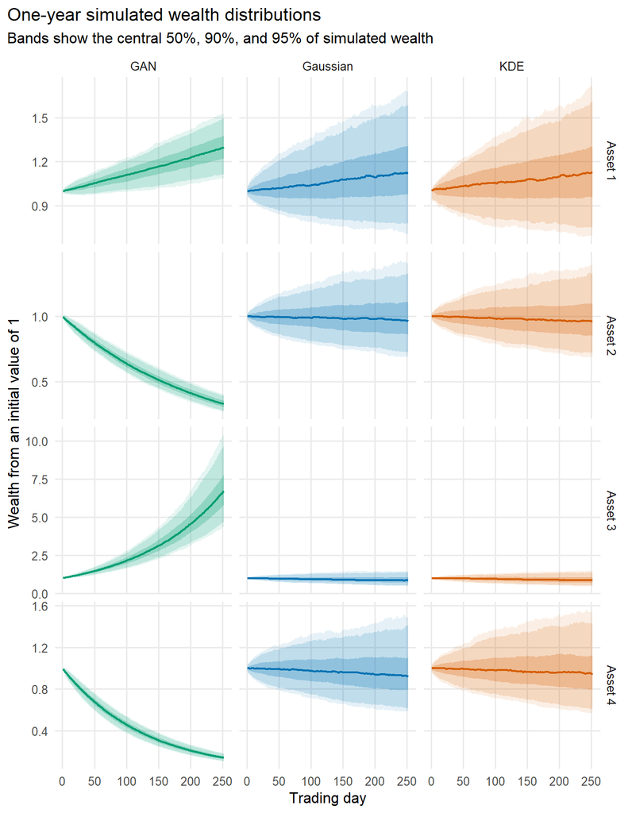

**TipQuestion**

How should we interpret a central 90% simulation band?

**NoteAnswer**

- At each horizon, the band runs from the 5th to the 95th percentile of the model-generated wealth distribution.
- It summarizes uncertainty conditional on the fitted model and calibration sample.
- It is not a guarantee that the realized path will remain inside the band.
- The bands are pointwise: one path may move inside and outside them over time.

**TipQuestion**

Why can terminal wealth be skewed even when daily returns are Gaussian?

**NoteAnswer**

- Wealth compounds multiplicatively rather than adding daily returns.
- Gains and losses have asymmetric effects on compounded wealth.
- The product of many $(1+r_t)$ terms is therefore not generally symmetric, even when the daily return distribution is symmetric.

### Compare planning outcomes

**CautionTask**

Compare the Gaussian and KDE models on the planning summaries that matter to the risk manager:

- downside risk, measured by Value at Risk and Expected Shortfall;
- the probability that terminal wealth falls below its starting value; and
- the typical maximum drawdown.

Starting with wealth equal to 1, define the one-year loss on path $p$ fpr asset $i$ as

$$L_{i,p}=1-W_{i,p,252}.$$

A positive value of $L_{i,p}$ represents a loss relative to starting wealth.

The 95% Value at Risk is the 95th percentile of the simulated loss distribution:

$$\operatorname{VaR}_{0.95}(L_i)
=
q_{0.95}(L_i).$$

It is the loss threshold exceeded by approximately the worst 5% of simulated paths. Expected Shortfall is the average loss among those worst 5% of paths:

$$\operatorname{ES}_{0.95}(L_i)
=
E\left[L_i\mid L_i\geq \operatorname{VaR}_{0.95}(L_i)\right].$$

Expected Shortfall is therefore sensitive not only to how often severe losses occur, but also to how severe those losses are once they occur.

```r
model_risk_comparison <- path_summary |>
  select(
    asset_id,
    model,
    median_terminal_wealth,
    probability_below_one,
    loss_var_95,
    loss_es_95,
    median_max_drawdown
  ) |>
  mutate(model = factor(model, levels = c("Gaussian", "KDE", "GAN"))) |>
  arrange(asset_id, model)

risk_differences <- model_risk_comparison |>
  select(asset_id, model, loss_var_95, loss_es_95) |>
  pivot_wider(
    names_from = model,
    values_from = c(loss_var_95, loss_es_95)
  ) |>
  transmute(
    asset_id,
    var_kde_minus_gaussian =
      loss_var_95_KDE - loss_var_95_Gaussian,
    es_kde_minus_gaussian =
      loss_es_95_KDE - loss_es_95_Gaussian,
    var_gan_minus_gaussian =
      loss_var_95_GAN - loss_var_95_Gaussian,
    es_gan_minus_gaussian =
      loss_es_95_GAN - loss_es_95_Gaussian
  )
```

**NoteOutput**

Planning outcomes by asset and model

| asset_id | model | median_terminal_wealth | probability_below_one | loss_var_95 | loss_es_95 | median_max_drawdown |
| --- | --- | --- | --- | --- | --- | --- |
| Asset 1 | Gaussian | 1.1205 | 28.9% | 21.6% | 29.4% | 17.8% |
| Asset 1 | KDE | 1.1238 | 30.0% | 24.3% | 31.6% | 18.6% |
| Asset 1 | GAN | 1.2958 | 0.1% | -11.9% | -8.4% | 4.0% |
| Asset 2 | Gaussian | 0.9651 | 56.2% | 27.8% | 32.2% | 19.2% |
| Asset 2 | KDE | 0.9598 | 57.9% | 28.0% | 32.6% | 19.9% |
| Asset 2 | GAN | 0.3304 | 100.0% | 72.1% | 73.3% | 67.1% |
| Asset 3 | Gaussian | 0.8580 | 69.1% | 48.3% | 52.9% | 32.2% |
| Asset 3 | KDE | 0.8582 | 69.4% | 48.6% | 55.6% | 32.4% |
| Asset 3 | GAN | 6.7032 | 0.0% | -370.5% | -332.7% | 5.2% |
| Asset 4 | Gaussian | 0.9201 | 60.8% | 38.5% | 43.4% | 26.7% |
| Asset 4 | KDE | 0.9495 | 58.3% | 39.4% | 44.5% | 25.7% |
| Asset 4 | GAN | 0.1402 | 100.0% | 89.0% | 89.6% | 86.0% |

KDE and GAN minus Gaussian downside risk; positive values indicate more severe risk than the Gaussian model

| asset_id | var_kde_minus_gaussian | es_kde_minus_gaussian | var_gan_minus_gaussian | es_gan_minus_gaussian |
| --- | --- | --- | --- | --- |
| Asset 1 | 2.7% | 2.1% | -33.4% | -37.9% |
| Asset 2 | 0.2% | 0.4% | 44.3% | 41.1% |
| Asset 3 | 0.2% | 2.7% | -418.8% | -385.6% |
| Asset 4 | 0.8% | 1.0% | 50.5% | 46.2% |

**NoteOutput**

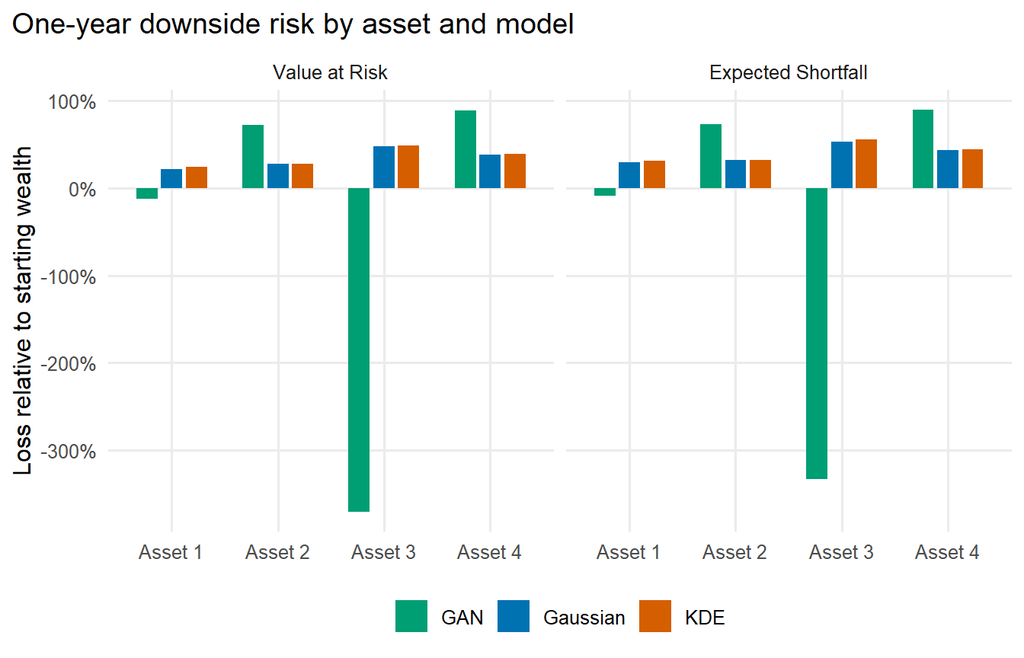

**TipQuestion**

Interpret the planning results. Which assets show the most important differences between the Gaussian and KDE models?

### Validation

The models were calibrated using the first four years of returns. We now evaluate them using the subsequent 252 daily returns that were not used during estimation.

A useful validation strategy should examine more than one statistic.

$\underline{\text{Log Score}}$

The goal is to approximate the unknown density that generates future returns. Call this unknown density $f_0$. Because $f_0$ is not observable, each fitted model provides a proxy $\widehat f_m$ for that density.

Suppose $r_t$ is one realized return from the validation period. For a continuous variable, the probability of observing exactly $r_t$ is zero. Instead, $\widehat f_m(r_t)$ measures the local concentration of probability around that realized return.

For model $m$, define the score for observation $r_t$ as

$$\ell_{m,t}
=
\log\left[\widehat f_m(r_t)\right].$$

The average validation log score is

$$\operatorname{LogScore}_m
=
\frac{1}{n}
\sum_{t=1}^{n}
\log\left[\widehat f_m(r_t)\right].$$

The validation average is an empirical estimate of

$$E_{R\sim f_0}
\left[
\log\left(\widehat f_m(R)\right)
\right],$$

the model’s expected log density when evaluated at a future return generated by the unknown process.

Consider a realized validation return of $r_t=-15\%$. Suppose the Gaussian model assigns essentially no density to returns near $-15\%$:

$$\widehat f_{\text{Gaussian}}(-0.15)=10^{-12}.$$

Its score for this observation is therefore

$$\log(10^{-12})\approx -27.63.$$

Now suppose the calibration sample contains an extreme loss near $-15\%$. The KDE places a kernel around that observation and assigns greater local density to returns near $-15\%$:

$$\widehat f_{\text{KDE}}(-0.15)=10^{-3}.$$

The KDE receives the score

$$\log(10^{-3})\approx -6.91.$$

Thus, KDE receives a substantially better score for this realized return:

$$-6.91-(-27.63)=20.72.$$

The KDE is rewarded because it assigned more density to the region where the return actually occurred. The Gaussian model is penalized because its fitted density regarded that outcome as extremely unlikely. The numerical density values above are illustrative; a density is not itself a probability and need not lie between zero and one.

The log score repeats this comparison for every validation return. A model can outperform another model because it assigns more density to important observations, particularly observations that the competing model regards as extremely unlikely. However, if KDE places too much density around unusual calibration observations that do not recur, it may perform worse on the remaining validation returns.

Higher average log scores are better. The logarithm strongly penalizes a model when it assigns extremely low density to a realized return, so the score rewards models that allocate density effectively across the full validation sample, including its tails.

$\underline{Coverage}$

For a nominal predictive interval $\left[\widehat q_{\alpha/2},\widehat q_{1-\alpha/2}\right]$, empirical coverage is

$$\operatorname{Coverage}_{1-\alpha}
=
\frac{1}{n}
\sum_{t=1}^{n}
\mathbf{1}
\left\{
\widehat q_{\alpha/2}
\leq r_t
\leq
\widehat q_{1-\alpha/2}
\right\}.$$

For example, a well-calibrated 90% interval should contain approximately 90% of the validation returns. We examine several interval levels because a model can have reasonable central coverage while still misrepresenting the tails.

$ $

The realized 5% tail frequency is

$$\operatorname{TailFrequency}_{0.05}
=
\frac{1}{n}
\sum_{t=1}^{n}
\mathbf{1}
\left\{
r_t\leq \widehat q_{0.05}
\right\}.$$

This should be compared with 0.05:

- a value above 0.05 suggests that the model underestimates the frequency of sufficiently bad returns;
- a value below 0.05 suggests that the model predicts too many bad returns.

Because the validation sample contains only 252 observations, these measures are subject to sampling variation. The validation evidence should therefore be interpreted as suggestive rather than definitive.

**CautionTask**

Use the custom validation_metrics function on the validation sample for each asset. Produce a table as well as bar chart of the log score for each asset under the Gaussian, KDE, and GAN approaches.

The GAN has no closed-form density, so `validation_metrics()` treats it the same way the in-sample density plot did: it draws a large reference sample from the trained generator and fits a KDE to that sample as a plug-in approximation to the GAN’s implied density. Coverage and tail frequency for the GAN are based directly on the quantiles of that same reference sample.

```r
validation_results <- map_dfr(seq_along(asset_levels), function(i) {
  id <- asset_levels[i]

  train_x <- calibration |>
    filter(asset_id == id) |>
    pull(return)

  validation_x <- validation |>
    filter(asset_id == id) |>
    pull(return)

  set.seed(800000 + i)

  validation_metrics(
    train = train_x,
    validation = validation_x,
    bandwidth = bw.nrd0(train_x),
    kde_quantile_draws = KDE_QUANTILE_DRAWS,
    gan_fit = gan_fits[[id]]
  ) |>
    mutate(asset_id = id, .before = 1)
}) |>
  mutate(
    asset_id = factor(asset_id, levels = asset_levels),
    model = factor(model, levels = c("Gaussian", "KDE", "GAN"))
  )
```

**NoteOutput**

Out-of-sample validation by asset and model

| asset_id | model | log_score | coverage_90 | coverage_95 | coverage_98 | predicted_q05 | realized_below_q05 |
| --- | --- | --- | --- | --- | --- | --- | --- |
| Asset 1 | Gaussian | 2.8859 | 95.2% | 95.2% | 95.2% | -2.2% | 4.8% |
| Asset 1 | KDE | 3.3972 | 91.3% | 96.0% | 97.2% | -1.3% | 5.6% |
| Asset 1 | GAN | 2.0792 | 78.6% | 84.5% | 90.5% | -0.8% | 9.5% |
| Asset 2 | Gaussian | 3.0465 | 90.1% | 96.0% | 97.6% | -1.9% | 4.8% |
| Asset 2 | KDE | 3.0463 | 90.5% | 96.4% | 96.8% | -1.9% | 4.4% |
| Asset 2 | GAN | 1.7527 | 58.7% | 66.7% | 78.6% | -1.6% | 7.5% |
| Asset 3 | Gaussian | 2.5073 | 90.9% | 93.3% | 95.2% | -3.0% | 6.7% |
| Asset 3 | KDE | 2.7409 | 87.7% | 93.3% | 96.4% | -2.9% | 6.7% |
| Asset 3 | GAN | 1.7647 | 85.3% | 90.5% | 92.5% | -1.5% | 12.3% |
| Asset 4 | Gaussian | 2.6654 | 90.9% | 92.9% | 94.4% | -2.6% | 4.0% |
| Asset 4 | KDE | 2.7509 | 90.5% | 93.7% | 97.2% | -2.6% | 4.0% |
| Asset 4 | GAN | 1.0100 | 61.9% | 71.0% | 78.2% | -2.4% | 4.4% |

**NoteOutput**

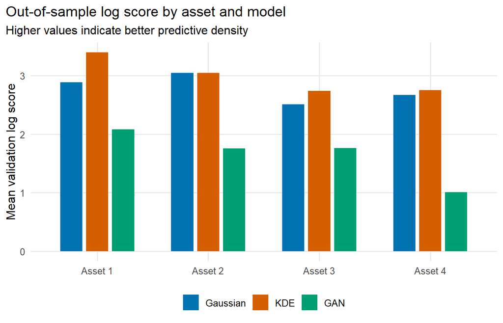

**TipQuestion**

Interpret the validation results. What do the log scores, coverage measures, and tail frequencies suggest?

**NoteAnswer**

- KDE has a higher validation log score for Assets 1, 3, and 4. For Asset 2, the two scores are essentially identical. The Gaussian model is therefore adequate for Asset 2, while KDE appears to assign more useful predictive density to the validation returns for the other three assets.
- The GAN has the lowest validation log score of the three models for every asset, consistent with the one-day and path-simulation comparisons above. Its interval coverage is particularly poor for Assets 2 and 4: the nominal 90% interval covers only about 59% and 62% of validation returns, respectively, versus approximately 90% for Gaussian and KDE. Its realized 5% tail frequency is also elevated for Assets 1-3 (around 7.5%-12.3%, versus roughly 5%-7% for Gaussian and KDE), reflecting the underestimated volatility documented earlier. This is a direct consequence of the small network and short training schedule used here, not an inherent property of GAN-based simulation.
- Asset 3 deserves particular attention. Both models realize a 5% tail frequency of approximately 6.75%, which is above the nominal 5% level. Both models therefore appear to underestimate the frequency of sufficiently bad daily returns for this asset.
- The coverage results are generally close to their nominal levels, but they are not identical across interval widths. This illustrates why evaluating only one predictive interval can conceal model weaknesses.
- Asset 4 has a realized 5% tail frequency below 5% under both models. In this validation sample, both models are somewhat conservative with respect to the frequency of very negative daily returns.
- The validation evidence does not identify one universally superior model. Log score evaluates the overall quality of the predictive density, while coverage and tail frequency focus on calibration at selected regions of the distribution. These measures provide complementary evidence.

**TipQuestion**

Why might KDE fit better in sample but produce a worse validation log score?

**NoteAnswer**

- A small bandwidth can cause KDE to adapt closely to idiosyncratic calibration-period observations.
- Those local features may reflect sampling noise and may not recur during the validation period.
- KDE can therefore have lower bias but higher variance than the Gaussian model.
- This is the same bias–variance tradeoff encountered throughout machine learning.

**TipQuestion**

Across every comparison in this document, how does the GAN’s reliability compare with the Gaussian and KDE models?

**NoteAnswer**

Across the in-sample density overlay, the one-day moment comparison, the one-year path simulations, and the out-of-sample validation metrics, the GAN as configured here is consistently the least reliable of the three models: it understates volatility, misses skewness and kurtosis almost entirely for the heavier-tailed assets, has the lowest validation log score for every asset, and – most consequentially – compounds small daily mean biases into economically large distortions in one-year planning outcomes.

This is not evidence that GANs are unsuitable for this task in general. It reflects a deliberate choice, made to keep this document fast to render, to train a small network for very few epochs. The Gaussian model requires estimating only two parameters per asset and matches the data by construction. KDE requires choosing a single bandwidth and is tied directly to the observed data, so it degrades gracefully. A GAN instead requires solving a genuinely difficult non-convex adversarial optimization problem with no such guardrail, and its quality depends on network size, training length, and random initialization in a way that neither of the other two models’ quality does. A fair comparison with a production-grade GAN would require considerably more architecture and training-time investment – and, even then, the comparison would still need the same validation discipline applied here, since nothing about a GAN’s flexibility guarantees a good fit.